# PCGR query report: **TP53**

2019-08-19 01:00:35

# TP53 metadata

Gene symbol: **TP53**  
UniProtKB ID: **P04637**  
Gene product name: **Cellular tumor antigen p53**  
Chromosome: **17**  
Strand: **-1**  
Number of unique Ensembl transcripts: **29**  
Number of unique Ensembl exons for all transcripts: **53**

## Primary representative transcript:

Ensembl transcript ID **ENST00000269305**  
Number of exons: **11**  
Transcript length: **2579**  
Coding sequence length: **1182**  
Transcript start position: **7668402**  
Transcript end position: **7687538**

# Protein features: Domains, Regions, Motifs and Modifications

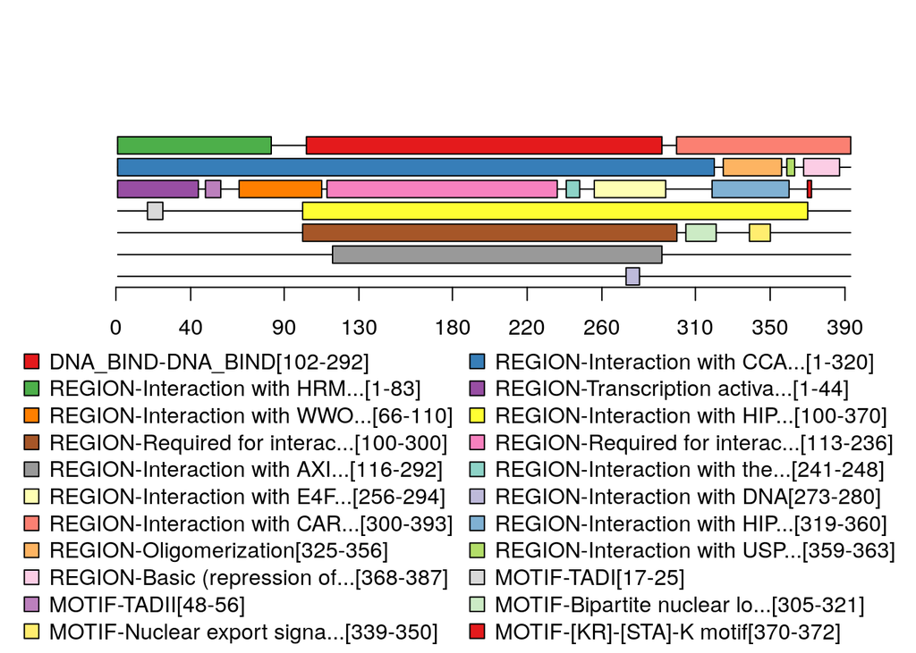

# All features (minus variants and sequence conflicts)

| TYPE | AA_start | AA_end | LABEL |
| --- | --- | --- | --- |
| CHAIN | 1 | 393 | Cellular tumor antigen p53 |
| DNA_BIND | 102 | 292 | DNA_BIND |
| REGION | 1 | 320 | Interaction with CCAR2 |
| REGION | 1 | 83 | Interaction with HRMT1L2 |
| REGION | 1 | 44 | Transcription activation (acidic) |
| REGION | 66 | 110 | Interaction with WWOX |
| REGION | 100 | 370 | Interaction with HIPK1 |
| REGION | 100 | 300 | Required for interaction with ZNF385A |
| REGION | 113 | 236 | Required for interaction with FBXO42 |
| REGION | 116 | 292 | Interaction with AXIN1 |
| REGION | 241 | 248 | Interaction with the 53BP2 SH3 domain |
| REGION | 256 | 294 | Interaction with E4F1 |
| REGION | 273 | 280 | Interaction with DNA |
| REGION | 300 | 393 | Interaction with CARM1 |
| REGION | 319 | 360 | Interaction with HIPK2 |
| REGION | 325 | 356 | Oligomerization |
| REGION | 359 | 363 | Interaction with USP7 |
| REGION | 368 | 387 | Basic (repression of DNA-binding) |
| MOTIF | 17 | 25 | TADI |
| MOTIF | 48 | 56 | TADII |
| MOTIF | 305 | 321 | Bipartite nuclear localization signal |
| MOTIF | 339 | 350 | Nuclear export signal |
| MOTIF | 370 | 372 | [KR]-[STA]-K motif |
| METAL | 176 | 176 | Zinc |
| METAL | 179 | 179 | Zinc |
| METAL | 238 | 238 | Zinc |
| METAL | 242 | 242 | Zinc |
| SITE | 120 | 120 | Interaction with DNA |
| MOD_RES | 9 | 9 | Phosphoserine; by HIPK4 |
| MOD_RES | 15 | 15 | Phosphoserine; by CDK5, PRPK, AMPK, NUAK1 and ATM |

[output cut: 68 more lines]

# Ensembl Transcripts

All transcripts are ploted to their relative genomic positions with all shared intronic regions removed. Transcription start sites are always on the left regardless of strand. **‘Main’ representative transcript used for variant alignment is in red**

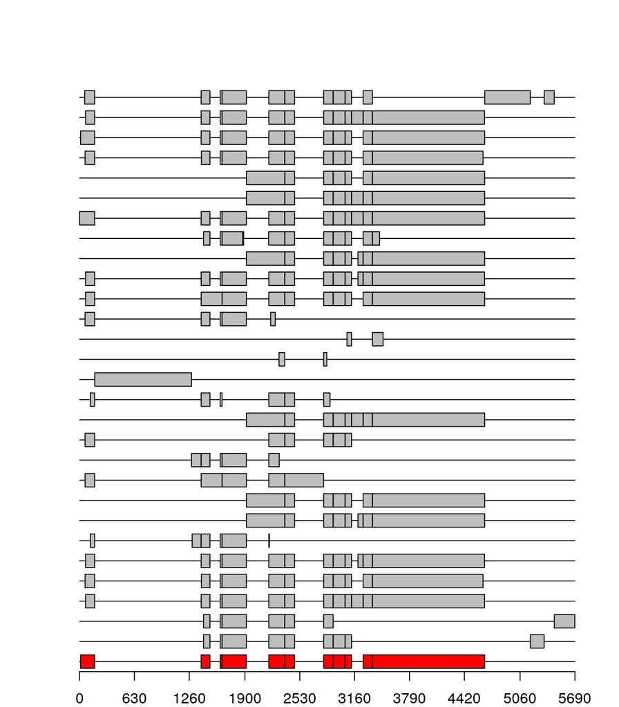

# Query metadata

Total number of studies returned by cBioPortal: **258**  
Total number of unique case IDs returned by cBioPortal: **49721**

Total number of studies with mutation/variant data available: **202**  
Total number of cases queried for **TP53** variants: **46087**  
Total number of studies with **TP53** variants: **178**  
Total number of unique cases represented in filtered mutation data: **13238**  
Total number of unique variants for **TP53** returned: **1995**

Cases with multiple variants

| Number of samples | Number of mutations per sample |
| --- | --- |
| 12182 | 1 |
| 1957 | 2 |
| 204 | 3 |
| 32 | 4 |
| 5 | 5 |

Tissue types in all cases

| Primary Tissue | Total cases in database | Total cases sequenced | Total altered cases | Percent altered |
| --- | --- | --- | --- | --- |
| Ampulla of Vater | 189 | 189 | 118 | 62.43 |
| Pituitary | 4 | 4 | 2 | 50.00 |
| Other | 1405 | 1405 | 698 | 49.68 |
| Head and Neck | 2435 | 1381 | 676 | 48.95 |
| Esophagus/Stomach | 3736 | 2260 | 1075 | 47.57 |
| Ovary/Fallopian Tube | 1943 | 857 | 404 | 47.14 |
| Pancreas | 1723 | 1519 | 716 | 47.14 |
| Bowel | 4760 | 3889 | 1416 | 36.41 |
| Appendix | 83 | 83 | 29 | 34.94 |
| Lung | 8160 | 6642 | 2237 | 33.68 |
| Skin | 3019 | 2274 | 708 | 31.13 |
| Breast | 10626 | 7896 | 2303 | 29.17 |
| Bladder/Urinary Tract | 2733 | 1751 | 509 | 29.07 |
| CNS/Brain | 5933 | 2546 | 703 | 27.61 |
| Uterus | 2154 | 1168 | 315 | 26.97 |
| Soft Tissue | 1474 | 803 | 196 | 24.41 |
| Biliary Tract | 1066 | 1030 | 250 | 24.27 |
| Liver | 1322 | 904 | 218 | 24.12 |
| Adrenal Gland | 219 | 127 | 28 | 22.05 |
| Prostate | 5661 | 4730 | 691 | 14.61 |
| Pleura | 321 | 234 | 30 | 12.82 |
| Bone | 376 | 376 | 43 | 11.44 |
| Myeloid | 1169 | 1169 | 124 | 10.61 |
| Germ Cell | 314 | 228 | 20 | 8.77 |
| Thyroid | 1864 | 868 | 69 | 7.95 |
| Lymphoid | 6885 | 5390 | 386 | 7.16 |
| Cervix | 663 | 366 | 23 | 6.28 |
| Kidney | 4003 | 2267 | 141 | 6.22 |
| Testis | 462 | 399 | 22 | 5.51 |
| Thymus | 300 | 177 | 7 | 3.95 |
| Peripheral Nervous System | 1709 | 398 | 5 | 1.26 |
| Eye | 84 | 4 | 0 | 0.00 |

# Gene fusions returned:

| case_id | amino_acid_change | genetic_profile_id |
| --- | --- | --- |
| P-0014583-T01-IM6 | TP53-intragenic | breast_msk_2018_mutations |
| P-0007205-T01-IM5 | TP53-SHBG fusion | chol_msk_2018_mutations |
| P-0020720-T01-IM6 | TP53-intragenic | hcc_mskimpact_2018_mutations |
| P-0001347-T02-IM5 | TP53-intragenic | msk_impact_2017_mutations |
| P-0003867-T01-IM5 | TP53-intragenic | msk_impact_2017_mutations |
| P-0004113-T01-IM5 | TP53-intragenic | msk_impact_2017_mutations |
| P-0004140-T02-IM5 | TP53-intragenic | msk_impact_2017_mutations |
| P-0004140-T03-IM5 | TP53-intragenic | msk_impact_2017_mutations |
| P-0004827-T01-IM5 | TP53-intragenic | msk_impact_2017_mutations |
| P-0005309-T01-IM5 | TP53-intragenic | msk_impact_2017_mutations |
| P-0005677-T01-IM5 | TP53-intragenic | msk_impact_2017_mutations |
| P-0006793-T01-IM5 | TP53-intragenic | msk_impact_2017_mutations |
| P-0007169-T01-IM5 | TP53-intragenic | msk_impact_2017_mutations |
| P-0009018-T01-IM5 | TP53-intragenic | msk_impact_2017_mutations |
| P-0009303-T01-IM5 | TP53-intragenic | msk_impact_2017_mutations |
| P-0009743-T01-IM5 | TP53-intragenic | msk_impact_2017_mutations |
| P-0010243-T01-IM5 | TP53-intragenic | msk_impact_2017_mutations |
| P-0011196-T01-IM5 | TP53-intragenic | msk_impact_2017_mutations |
| P-0011550-T01-IM5 | TP53-intragenic | msk_impact_2017_mutations |
| P-0009702-T01-IM5 | PSMD14-TP53 fusion | msk_impact_2017_mutations |
| P-0005011-T01-IM5 | TP53-GPS2 fusion | msk_impact_2017_mutations |
| P-0002304-T01-IM3 | TP53-SHBG fusion | msk_impact_2017_mutations |
| P-0007205-T01-IM5 | TP53-SHBG fusion | msk_impact_2017_mutations |
| P-0009044-T01-IM5 | ANTXR2-TP53 fusion | msk_impact_2017_mutations |
| P-0005976-T01-IM5 | TP53-ACAP1 fusion | msk_impact_2017_mutations |
| P-0005698-T01-IM5 | TP53-DLG4 fusion | msk_impact_2017_mutations |
| P-0002304-T01-IM3 | SPDYE4-TP53 fusion | msk_impact_2017_mutations |
| P-0011196-T01-IM5 | DLEU7-TP53 fusion | msk_impact_2017_mutations |
| P-0009687-T01-IM5 | SPG11-TP53 fusion | msk_impact_2017_mutations |
| P-0000206-T01-IM3 | TP53-ATP1B2 fusion | msk_impact_2017_mutations |

[output cut: 51 more lines]

# All variants returned

[figure not shown]

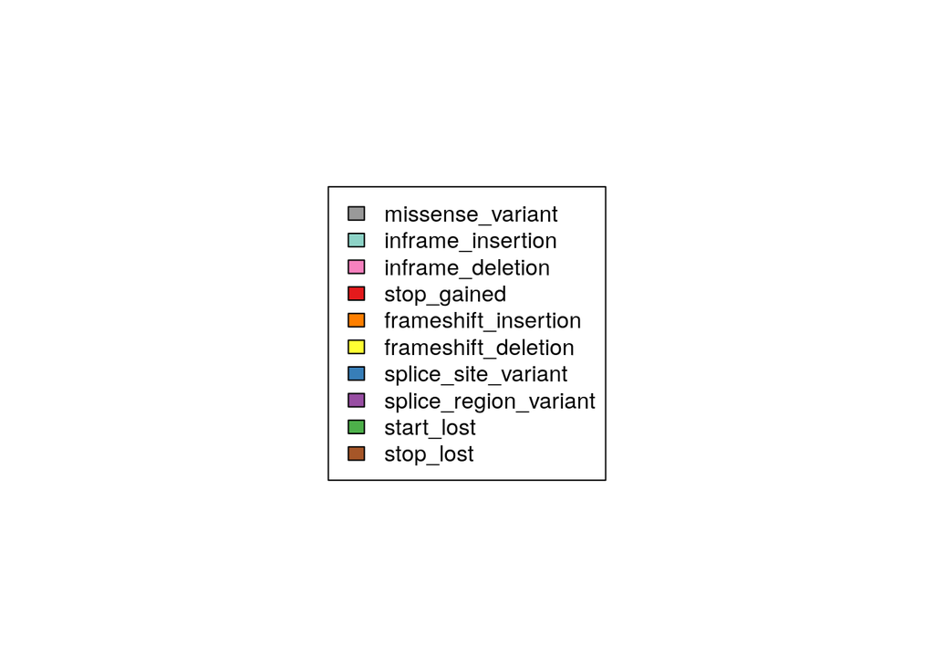

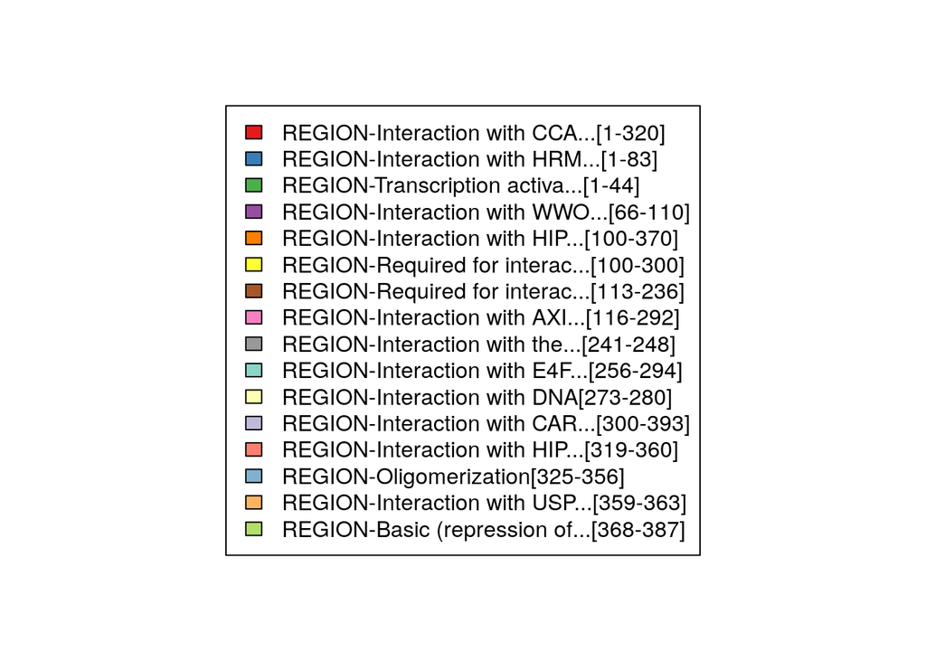